# Assignment 2_Zilin Lu

This is a guideline of my Assignment 2 to help you have a rough idea what you are going to see.

### Data Description:

1. Data I have: 15 homes with single occupancy (8 IDEAL homes, data collected in 2017/2018; 7 SMILE homes, data collected in 2020); Personal info of SMILE Homes
2. Data used in this notebook: 3 IDEAL homes and 5 SMILE homes (typically microwave files); Personal info of SMILE Homes

### Cleaning Template

How do I sort out repetitive time periods in the file?

### Data Analysis

#### SMILE Homes

1. Age v.s. Average Frequency
2. Location v.s. Average Frequency

#### IDEAL Homes

1. Home105 as an example (detailed analysis process)
2. Home90/106 added, general analysis

### Reflection and Hypotheses

# Part 1: General Description of Data

```python
import glob,os

path_IDEAL="/Users/luzilin/Desktop/study/y1s1/ds4d/assignment/assignment 2/IAM_Data/IDEAL"
files_IDEAL=glob.glob(os.path.join(path_IDEAL,"*.csv"))

path_SMILE="/Users/luzilin/Desktop/study/y1s1/ds4d/assignment/assignment 2/IAM_Data/SMILE"
files_SMILE=glob.glob(os.path.join(path_SMILE,"*.csv"))

print(len(files_IDEAL))
print(len(files_SMILE))
```

```
51
27
```

51 appliances data from 8 IDEAL homes; 27 appliances data from 7 SMILE homes.

```python
import pandas as pd

files_IDEAL0=pd.read_csv(files_IDEAL[0])
print(files_IDEAL0)
print(files_IDEAL0.dtypes)

files_IDEAL1=pd.read_csv(files_IDEAL[1])
print(files_IDEAL1)
print(files_IDEAL1.dtypes)
```

```
       2017/4/11 10:00  250
0      2017/4/11 10:00    0
1      2017/4/11 10:00    0
2      2017/4/11 10:17    0
3      2017/4/11 10:20    0
4      2017/4/11 10:33    0
...                ...  ...
13090  2018/6/30 19:48    0
13091  2018/6/30 20:48    0
13092  2018/6/30 21:48    0
13093  2018/6/30 22:48    0
13094  2018/6/30 23:48    0

[13095 rows x 2 columns]
2017/4/11 10:00    object
```

[output cut: 19 more lines]

Each csvfile has two columns of data: time(obj); power(int). But different files have different amounts of data due to different appliances. Also, these files don't have a tilte for each column.

# Part 2: Cleaning Template

This is a template of how I am going to clean the repetitive data in a csvfile.

```python
import pandas as pd
file=pd.read_csv(files_IDEAL[0],header=0,names=["time","power"])
lst=file["time"]
slst=set(lst)
if len(slst)==len(lst):
    print("OK")
else:
    print("NO")
```

```
NO
```

"NO" here means there are repeated items in "time", so in the next step I am going to get them out of the csvfile. This doesn't mean I have to delete them all. Actually I plan to pick out all the repeated items in the csvfile and use "reverse" to sort out all the other unique items.

```python
dlt_lst=[]
for i in range(0,len(lst)-1):
    if lst[i]==lst[i+1]:
        dlt_lst.append(lst[i+1])

nfile=file[~file["time"].isin(dlt_lst)]
nfile
```

|  | time | power |
| --- | --- | --- |
| 2 | 2017/4/11 10:17 | 0 |
| 3 | 2017/4/11 10:20 | 0 |
| 17 | 2017/4/11 10:52 | 2286 |
| 20 | 2017/4/11 11:20 | 0 |
| 21 | 2017/4/11 12:20 | 0 |
| ... | ... | ... |
| 13090 | 2018/6/30 19:48 | 0 |
| 13091 | 2018/6/30 20:48 | 0 |
| 13092 | 2018/6/30 21:48 | 0 |
| 13093 | 2018/6/30 22:48 | 0 |
| 13094 | 2018/6/30 23:48 | 0 |

10717 rows × 2 columns

```python
nlst=nfile["time"]
slst=set(nlst)
if len(slst)==len(nlst):
    assert True
else:
    assert False,"Something's wrong there!"
```

# Part 3: Data Analysis

# 1. IDEAL

I pick Home105 as an example to detailedly explain what and why I do this thing. For other IDEAL homes, I pick out another two to analyze the routines, frequencies and proportions. The reason why I only analyze part of homes is because the programming lines are similar and I would just like to figure out the possibility for answering the questions in Assignment 2. More analysis for whole homes will be conducted in Assignment 3.

## 1.1 Home105 As An Example

## First try in analyzing the routine

The sensors recorded the real-time power, which meant normally the power of appliances was still at 0 or fluctuated slightly around a small number, but once the user started to use, the number soared immediately. What I want to do is to sort out the "soar" process to get the time period.

### kettle use

```python
import pandas as pd

#check the file first
file=pd.read_csv("home105_kitchen1110_sensor5283_electric-appliance_kettle.csv", header=0, names=["time","power"])
lst=file["time"]
nlst=set(lst)
if len(nlst)==len(lst):
    print("OK")
else:
    print("NO")
```

```
OK
```

```python
import pandas as pd

#open csv file while add a title for each column
data=pd.read_csv("home105_kitchen1110_sensor5283_electric-appliance_kettle.csv", header=0, names=["time","power"])

#add new column for further cleaning use
data=pd.concat([data,pd.DataFrame(columns=list("a"))])

print(data.describe(include="object"))
data
```

```
                       time    a
count                 13488    0
unique                13488    0
top     2018-03-05 17:26:05  NaN
freq                      1  NaN
```

|  | time | power | a |
| --- | --- | --- | --- |
| 0 | 2017-05-18 11:52:53 | 2279.0 | NaN |
| 1 | 2017-05-18 11:53:00 | 0.0 | NaN |
| 2 | 2017-05-18 11:53:31 | 0.0 | NaN |
| 3 | 2017-05-18 11:53:32 | 0.0 | NaN |
| 4 | 2017-05-18 11:53:33 | 0.0 | NaN |
| ... | ... | ... | ... |
| 13483 | 2018-06-23 16:55:39 | 2256.0 | NaN |
| 13484 | 2018-06-23 16:56:37 | 1292.0 | NaN |
| 13485 | 2018-06-23 16:56:39 | 0.0 | NaN |
| 13486 | 2018-06-23 17:40:25 | 0.0 | NaN |
| 13487 | 2018-06-23 18:40:25 | 0.0 | NaN |

13488 rows × 3 columns

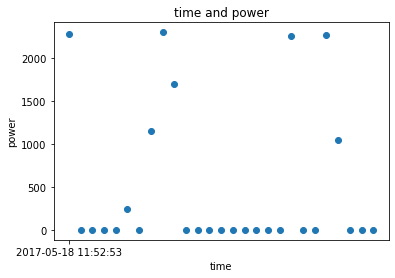

```python
import matplotlib.pyplot as plt
from matplotlib.pyplot import MultipleLocator
%matplotlib inline

#get a rough view of time and power in a day
data.index=pd.to_datetime(data["time"])
wdata=data.loc["2017-05-18"]

x=wdata["time"]
y=wdata["power"]
fig=plt.figure()
chart=fig.add_subplot(111)

chart.set_title("time and power")
plt.xlabel("time")
plt.ylabel("power")

y_major_locator=MultipleLocator(1000)
ax=plt.gca()
ax.xaxis.set_major_locator(y_major_locator)

chart.scatter(x,y)
plt.show()
```

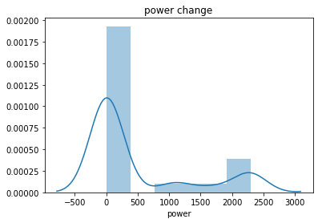

```python
import seaborn as sns
import matplotlib.pyplot as plt
%matplotlib inline

chart=sns.distplot(wdata["power"])
chart.set_title("power change")

plt.show()
```

```python
wdata=data[data["power"]!=0]
print("max:",wdata["power"].max())
print("min:",wdata["power"].min())
print("mean:",wdata["power"].mean())
```

```
max: 2393.0
min: 1.0
mean: 1694.474290780142
```

Two cells above help me confirm followings: when not using the kettle, the power is still at 0; when using the kettle, the highest power it can reach is 2393w, and on average fluctuate around 1695w.

```python
data["result"]=data["power"].shift(-1)-data["power"]
data["a"]=0

#choose 2000 as the bottom line to sort out the "must-use" periods
data.loc[data["result"]>2000,"a"]=1

#sort out the starting points
ndata=data[data["a"]==1]

ndata.index=pd.to_datetime(ndata["time"])
ndata
```

| time | time | power | a | result |
| --- | --- | --- | --- | --- |
| 2017-05-18 20:17:04 | 2017-05-18 20:17:04 | 0.0 | 1 | 2264.0 |
| 2017-05-18 21:17:05 | 2017-05-18 21:17:05 | 0.0 | 1 | 2268.0 |
| 2017-05-19 05:17:06 | 2017-05-19 05:17:06 | 0.0 | 1 | 2311.0 |
| 2017-05-19 08:49:02 | 2017-05-19 08:49:02 | 226.0 | 1 | 2030.0 |
| 2017-05-19 10:17:06 | 2017-05-19 10:17:06 | 0.0 | 1 | 2245.0 |
| ... | ... | ... | ... | ... |
| 2018-06-22 20:40:25 | 2018-06-22 20:40:25 | 0.0 | 1 | 2314.0 |
| 2018-06-23 02:43:29 | 2018-06-23 02:43:29 | 325.0 | 1 | 2031.0 |
| 2018-06-23 03:40:25 | 2018-06-23 03:40:25 | 0.0 | 1 | 2345.0 |
| 2018-06-23 10:40:25 | 2018-06-23 10:40:25 | 0.0 | 1 | 2307.0 |
| 2018-06-23 16:33:21 | 2018-06-23 16:33:21 | 25.0 | 1 | 2266.0 |

1013 rows × 4 columns

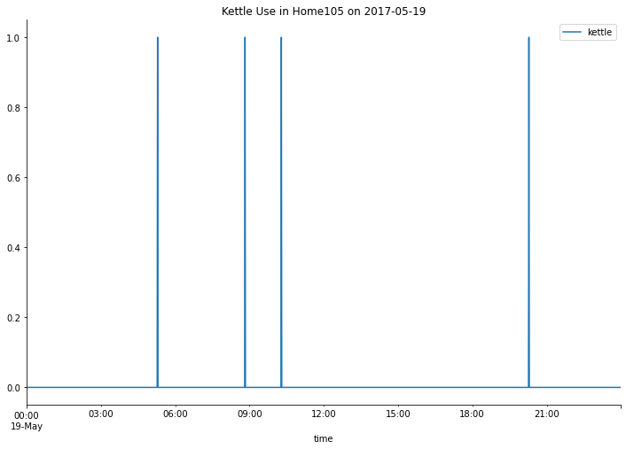

```python
nndata=ndata['time'].resample('T').count()
nnndata=nndata['2017-05-19':'2017-05-19']

import matplotlib.pyplot as plt
import seaborn as sns
%matplotlib inline

nnndata.plot(figsize=(12,8))
plt.legend(["kettle"])
plt.title("Kettle Use in Home105 on 2017-05-19")
sns.despine()
```

The figure means that home105 used the kettle at least 4 times on 2017-05-19, and the time periods were before 6am(1), between 9-11am(2), near 21pm(1). By changing the dates, I should be able to find out the habits/routines of home105 using kettle.

### fridgefreezer use

```python
import pandas as pd
file=pd.read_csv("home105_kitchen1110_sensor5284_electric-appliance_fridgefreezer.csv", header=0, names=["time","power"])
lst=file["time"]
nlst=set(lst)
if len(nlst)==len(lst):
    print("OK")
else:
    print("NO")
```

```
OK
```

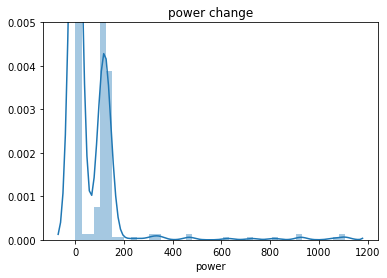

```python
import pandas as pd
import seaborn as sns
import matplotlib.pyplot as plt
%matplotlib inline

data1 = pd.read_csv("home105_kitchen1110_sensor5284_electric-appliance_fridgefreezer.csv", header=0, names=["time","power"])
data1 = pd.concat([data1,pd.DataFrame(columns=list("a"))])

data1.index=pd.to_datetime(data1["time"])
wdata1=data1.loc["2017-05-19"]
chart=sns.distplot(wdata1["power"])
chart.set_title("power change")

plt.ylim(0,0.005)
plt.show()
```

```python
wdata1=data1[data1["power"]!=0]
print("max:",wdata1["power"].max())
print("min:",wdata1["power"].min())
```

```
max: 1203.0
min: 1.0
```

```python
data1["a"]=0
data1.loc[data1["power"]>1000,"a"]=1
ndata1=data1[data1["a"]==1]
ndata1.index=pd.to_datetime(ndata1["time"])
ndata1
```

| time | time | power | a |
| --- | --- | --- | --- |
| 2017-05-18 12:18:27 | 2017-05-18 12:18:27 | 1141.0 | 1 |
| 2017-05-18 22:06:13 | 2017-05-18 22:06:13 | 1031.0 | 1 |
| 2017-05-19 01:47:01 | 2017-05-19 01:47:01 | 1105.0 | 1 |
| 2017-05-19 18:14:01 | 2017-05-19 18:14:01 | 1059.0 | 1 |
| 2017-05-19 19:24:27 | 2017-05-19 19:24:27 | 1108.0 | 1 |
| ... | ... | ... | ... |
| 2017-12-30 08:19:46 | 2017-12-30 08:19:46 | 1117.0 | 1 |
| 2017-12-30 09:00:16 | 2017-12-30 09:00:16 | 1008.0 | 1 |
| 2017-12-30 19:10:37 | 2017-12-30 19:10:37 | 1166.0 | 1 |
| 2017-12-31 00:22:13 | 2017-12-31 00:22:13 | 1155.0 | 1 |
| 2017-12-31 15:48:05 | 2017-12-31 15:48:05 | 1030.0 | 1 |

833 rows × 3 columns

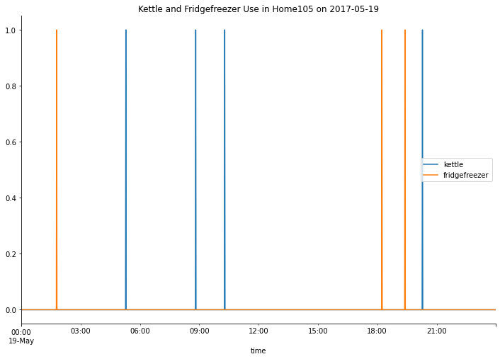

```python
import matplotlib.pyplot as plt
import seaborn as sns
%matplotlib inline

#combine plots to see the routine of home 105 using two appliances
nndata=ndata['time'].resample('T').count()
nnndata=nndata['2017-05-19':'2017-05-19']

nndata1=ndata1['time'].resample('T').count()
nnndata1=nndata1['2017-05-19':'2017-05-19']

nnndata.plot(figsize=(12,8))
nnndata1.plot(figsize=(12,8))
plt.legend(["kettle","fridgefreezer"])
plt.title("Kettle and Fridgefreezer Use in Home105 on 2017-05-19")
sns.despine()
sns.despine()
```

The figure combines two plots to see how home105 use both the kettle and fridgefreezer at the same day. By adding more appliances, the routine of home105 will gradually appear.

### washingmachine use

```python
import pandas as pd
file=pd.read_csv("home105_kitchen1110_sensor5285_electric-appliance_washingmachine.csv", header=0, names=["time","power"])
lst=file["time"]
nlst=set(lst)
if len(nlst)==len(lst):
    print("OK")
else:
    print("NO")
```

```
OK
```

```python
import pandas as pd
import seaborn as sns
import matplotlib.pyplot as plt
%matplotlib inline

data2 = pd.read_csv("home105_kitchen1110_sensor5285_electric-appliance_washingmachine.csv", header=0, names=["time","power"])
data2 = pd.concat([data2,pd.DataFrame(columns=list("a"))])

data2.index=pd.to_datetime(data2["time"])
data2["result"]=data2["power"].shift(-1)-data2["power"]
data2["a"]=0
data2.loc[data2["result"]>2500,"a"]=1
ndata2=data2[data2["a"]==1]
ndata2.index=pd.to_datetime(ndata2["time"])
ndata2
```

| time | time | power | a | result |
| --- | --- | --- | --- | --- |
| 2017-05-20 16:05:33 | 2017-05-20 16:05:33 | 10.0 | 1 | 2879.0 |
| 2017-05-20 16:20:23 | 2017-05-20 16:20:23 | 161.0 | 1 | 2749.0 |
| 2017-05-21 07:44:27 | 2017-05-21 07:44:27 | 13.0 | 1 | 2776.0 |
| 2017-05-21 07:45:44 | 2017-05-21 07:45:44 | 13.0 | 1 | 2779.0 |
| 2017-05-21 07:59:19 | 2017-05-21 07:59:19 | 13.0 | 1 | 2792.0 |
| ... | ... | ... | ... | ... |
| 2018-05-30 18:12:57 | 2018-05-30 18:12:57 | 7.0 | 1 | 2987.0 |
| 2018-06-01 14:18:32 | 2018-06-01 14:18:32 | 9.0 | 1 | 3033.0 |
| 2018-06-01 14:33:14 | 2018-06-01 14:33:14 | 7.0 | 1 | 2921.0 |
| 2018-06-02 12:51:28 | 2018-06-02 12:51:28 | 10.0 | 1 | 2945.0 |
| 2018-06-02 13:06:12 | 2018-06-02 13:06:12 | 7.0 | 1 | 2927.0 |

111 rows × 4 columns

### microwave use

```python
import pandas as pd
file=pd.read_csv("home105_kitchen1110_sensor5286_electric-appliance_microwave.csv", header=0, names=["time","power"])
lst=file["time"]
nlst=set(lst)
if len(nlst)==len(lst):
    print("OK")
else:
    print("NO")
```

```
OK
```

```python
import pandas as pd
import seaborn as sns
import matplotlib.pyplot as plt
%matplotlib inline

data3 = pd.read_csv("home105_kitchen1110_sensor5286_electric-appliance_microwave.csv", header=0, names=["time","power"])
data3 = pd.concat([data3,pd.DataFrame(columns=list("a"))])

data3.index=pd.to_datetime(data3["time"])
data3["result"]=data3["power"].shift(-1)-data3["power"]
data3["a"]=0
data3.loc[data3["result"]>1000,"a"]=1
ndata3=data3[data3["a"]==1]
ndata3.index=pd.to_datetime(ndata3["time"])
ndata3
```

| time | time | power | a | result |
| --- | --- | --- | --- | --- |
| 2017-05-18 12:09:22 | 2017-05-18 12:09:22 | 203.0 | 1 | 1207.0 |
| 2017-05-18 12:14:08 | 2017-05-18 12:14:08 | 196.0 | 1 | 1115.0 |
| 2017-05-19 11:40:20 | 2017-05-19 11:40:20 | 184.0 | 1 | 1225.0 |
| 2017-05-19 12:26:42 | 2017-05-19 12:26:42 | 190.0 | 1 | 1183.0 |
| 2017-05-19 18:47:42 | 2017-05-19 18:47:42 | 152.0 | 1 | 1177.0 |
| ... | ... | ... | ... | ... |
| 2018-05-26 18:44:36 | 2018-05-26 18:44:36 | 198.0 | 1 | 1051.0 |
| 2018-05-27 18:57:33 | 2018-05-27 18:57:33 | 257.0 | 1 | 1158.0 |
| 2018-05-28 19:11:15 | 2018-05-28 19:11:15 | 206.0 | 1 | 1224.0 |
| 2018-05-28 19:19:23 | 2018-05-28 19:19:23 | 206.0 | 1 | 1057.0 |
| 2018-06-23 11:32:16 | 2018-06-23 11:32:16 | 190.0 | 1 | 1215.0 |

681 rows × 4 columns

### dishwasher use

```python
import pandas as pd
file=pd.read_csv("home105_kitchen1110_sensor5287_electric-appliance_dishwasher.csv", header=0, names=["time","power"])
lst=file["time"]
nlst=set(lst)
if len(nlst)==len(lst):
    print("OK")
else:
    print("NO")
```

```
OK
```

```python
import pandas as pd
import seaborn as sns
import matplotlib.pyplot as plt
%matplotlib inline

data4 = pd.read_csv("home105_kitchen1110_sensor5287_electric-appliance_dishwasher.csv", header=0, names=["time","power"])
data4 = pd.concat([data4,pd.DataFrame(columns=list("a"))])

data4.index=pd.to_datetime(data4["time"])
data4["result"]=data4["power"].shift(-1)-data4["power"]
data4["a"]=0
data4.loc[data4["result"]>2000,"a"]=1
ndata4=data4[data4["a"]==1]
ndata4.index=pd.to_datetime(ndata4["time"])
ndata4
```

| time | time | power | a | result |
| --- | --- | --- | --- | --- |
| 2017-05-28 13:49:30 | 2017-05-28 13:49:30 | 64.0 | 1 | 2533.0 |
| 2017-05-28 15:03:30 | 2017-05-28 15:03:30 | 73.0 | 1 | 2522.0 |
| 2017-06-04 17:50:08 | 2017-06-04 17:50:08 | 72.0 | 1 | 2413.0 |
| 2017-06-10 18:14:27 | 2017-06-10 18:14:27 | 447.0 | 1 | 2052.0 |
| 2017-06-16 18:19:19 | 2017-06-16 18:19:19 | 69.0 | 1 | 2493.0 |
| ... | ... | ... | ... | ... |
| 2018-05-29 19:29:18 | 2018-05-29 19:29:18 | 69.0 | 1 | 2332.0 |
| 2018-05-29 20:02:32 | 2018-05-29 20:02:32 | 65.0 | 1 | 2413.0 |
| 2018-05-29 20:50:06 | 2018-05-29 20:50:06 | 211.0 | 1 | 2278.0 |
| 2018-06-02 21:12:28 | 2018-06-02 21:12:28 | 69.0 | 1 | 2565.0 |
| 2018-06-02 21:30:24 | 2018-06-02 21:30:24 | 67.0 | 1 | 2272.0 |

91 rows × 4 columns

### vacuumcleaner use

```python
import pandas as pd
file=pd.read_csv("home105_kitchen1110_sensor7932_electric-appliance_vacuumcleaner.csv", header=0, names=["time","power"])
lst=file["time"]
nlst=set(lst)
if len(nlst)==len(lst):
    print("OK")
else:
    print("NO")
```

```
OK
```

```python
import pandas as pd
import seaborn as sns
import matplotlib.pyplot as plt
%matplotlib inline

data5 = pd.read_csv("home105_kitchen1110_sensor7932_electric-appliance_vacuumcleaner.csv", header=0, names=["time","power"])
data5 = pd.concat([data3,pd.DataFrame(columns=list("a"))])

data5.index=pd.to_datetime(data5["time"])
data5["result"]=data5["power"].shift(-1)-data5["power"]
data5["a"]=0
data5.loc[data5["result"]>1000,"a"]=1
ndata5=data5[data5["a"]==1]
ndata5.index=pd.to_datetime(ndata5["time"])
ndata5
```

| time | time | power | a | result |
| --- | --- | --- | --- | --- |
| 2017-05-18 12:09:22 | 2017-05-18 12:09:22 | 203.0 | 1 | 1207.0 |
| 2017-05-18 12:14:08 | 2017-05-18 12:14:08 | 196.0 | 1 | 1115.0 |
| 2017-05-19 11:40:20 | 2017-05-19 11:40:20 | 184.0 | 1 | 1225.0 |
| 2017-05-19 12:26:42 | 2017-05-19 12:26:42 | 190.0 | 1 | 1183.0 |
| 2017-05-19 18:47:42 | 2017-05-19 18:47:42 | 152.0 | 1 | 1177.0 |
| ... | ... | ... | ... | ... |
| 2018-05-26 18:44:36 | 2018-05-26 18:44:36 | 198.0 | 1 | 1051.0 |
| 2018-05-27 18:57:33 | 2018-05-27 18:57:33 | 257.0 | 1 | 1158.0 |
| 2018-05-28 19:11:15 | 2018-05-28 19:11:15 | 206.0 | 1 | 1224.0 |
| 2018-05-28 19:19:23 | 2018-05-28 19:19:23 | 206.0 | 1 | 1057.0 |
| 2018-06-23 11:32:16 | 2018-06-23 11:32:16 | 190.0 | 1 | 1215.0 |

681 rows × 4 columns

## Routines (all recorded appliances in Home105)

Now all recorded appliances in Home105 are on the plots. By changing the date, I can tell the routine of appliance use day by day.

I randomly picked out three days: 2017-05-28, 2017-06-01, 2017-08-01 to see the timelines change in all recorded appliances.

What I want to find out are the followings:

1. Did Home105 have a routine in using appliances in one day?
2. Did the routine corresponding to typical appliances?

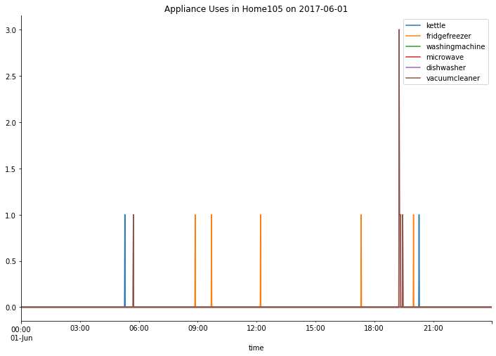

```python
import matplotlib.pyplot as plt
import seaborn as sns
%matplotlib inline

#combine plots to see the routine of home 105 using two appliances
nndata=ndata['time'].resample('T').count()
nnndata=nndata['2017-06-01':'2017-06-01']

nndata1=ndata1['time'].resample('T').count()
nnndata1=nndata1['2017-06-01':'2017-06-01']

nndata2=ndata2['time'].resample('T').count()
nnndata2=nndata2['2017-06-01':'2017-06-01']

nndata3=ndata3['time'].resample('T').count()
nnndata3=nndata3['2017-06-01':'2017-06-01']

nndata4=ndata4['time'].resample('T').count()
nnndata4=nndata4['2017-06-01':'2017-06-01']

nndata5=ndata5['time'].resample('T').count()
nnndata5=nndata5['2017-06-01':'2017-06-01']

nnndata.plot(figsize=(12,8))
nnndata1.plot(figsize=(12,8))
nnndata2.plot(figsize=(12,8))
nnndata3.plot(figsize=(12,8))
nnndata4.plot(figsize=(12,8))
nnndata5.plot(figsize=(12,8))
plt.legend(["kettle","fridgefreezer","washingmachine","microwave","dishwasher","vacuumcleaner"])
plt.title("Appliance Uses in Home105 on 2017-06-01")
sns.despine()
```

Add plots of 2017-05-28, 2017-08-01 to see if a routine existed.

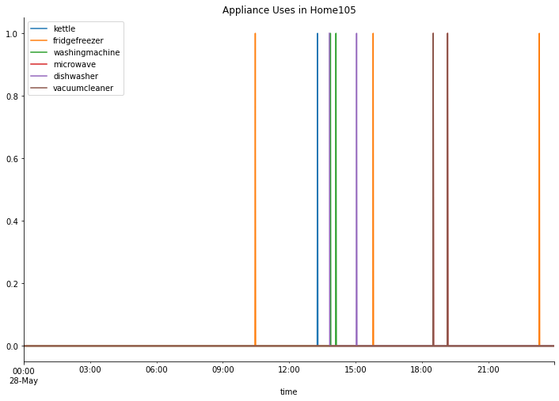

```python
import matplotlib.pyplot as plt
import seaborn as sns
%matplotlib inline

#combine plots to see the routine of home 105 using two appliances
nndata=ndata['time'].resample('T').count()
nnndata=nndata['2017-05-28':'2017-05-28']

nndata1=ndata1['time'].resample('T').count()
nnndata1=nndata1['2017-05-28':'2017-05-28']

nndata2=ndata2['time'].resample('T').count()
nnndata2=nndata2['2017-05-28':'2017-05-28']

nndata3=ndata3['time'].resample('T').count()
nnndata3=nndata3['2017-05-28':'2017-05-28']

nndata4=ndata4['time'].resample('T').count()
nnndata4=nndata4['2017-05-28':'2017-05-28']

nndata5=ndata5['time'].resample('T').count()
nnndata5=nndata5['2017-05-28':'2017-05-28']

nnndata.plot(figsize=(12,8))
nnndata1.plot(figsize=(12,8))
nnndata2.plot(figsize=(12,8))
nnndata3.plot(figsize=(12,8))
nnndata4.plot(figsize=(12,8))
nnndata5.plot(figsize=(12,8))
plt.legend(["kettle","fridgefreezer","washingmachine","microwave","dishwasher","vacuumcleaner"])
plt.title("Appliance Uses in Home105")
sns.despine()
```

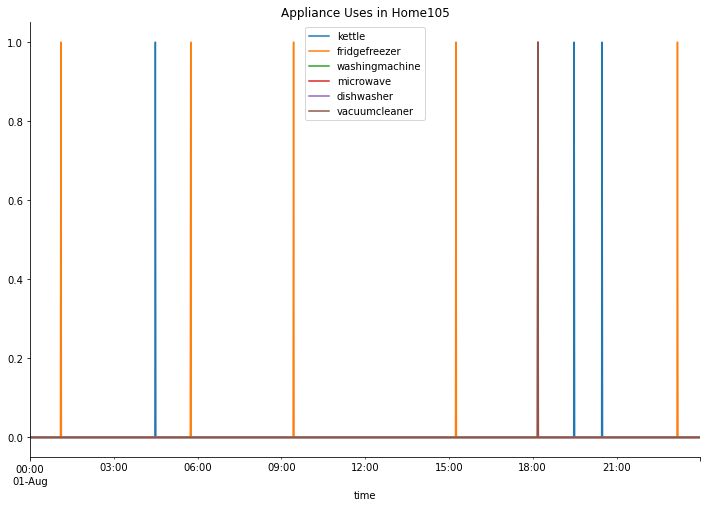

```python
import matplotlib.pyplot as plt
import seaborn as sns
%matplotlib inline

#combine plots to see the routine of home 105 using two appliances
nndata=ndata['time'].resample('T').count()
nnndata=nndata['2017-08-01':'2017-08-01']

nndata1=ndata1['time'].resample('T').count()
nnndata1=nndata1['2017-08-01':'2017-08-01']

nndata2=ndata2['time'].resample('T').count()
nnndata2=nndata2['2017-08-01':'2017-08-01']

nndata3=ndata3['time'].resample('T').count()
nnndata3=nndata3['2017-08-01':'2017-08-01']

nndata4=ndata4['time'].resample('T').count()
nnndata4=nndata4['2017-08-01':'2017-08-01']

nndata5=ndata5['time'].resample('T').count()
nnndata5=nndata5['2017-08-01':'2017-08-01']

nnndata.plot(figsize=(12,8))
nnndata1.plot(figsize=(12,8))
nnndata2.plot(figsize=(12,8))
nnndata3.plot(figsize=(12,8))
nnndata4.plot(figsize=(12,8))
nnndata5.plot(figsize=(12,8))
plt.legend(["kettle","fridgefreezer","washingmachine","microwave","dishwasher","vacuumcleaner"])
plt.title("Appliance Uses in Home105")
sns.despine()
```

To be honest, it is rather difficult to tell the rountine of one's life by only viewing three days. However, I still find out some similarities in them:

## Frequencies

The former programming puts emphasis on the timeline/routine of appliance uses in a day. In this part, I would like to look through the data from a more general aspect.

```python
#to know the frequencies of appliance use every day in a home
ndata["a"].resample("D").count()
```

```
time
2017-05-18    2
2017-05-19    4
2017-05-20    0
2017-05-21    7
2017-05-22    1
             ..
2018-06-19    0
2018-06-20    0
2018-06-21    0
2018-06-22    1
2018-06-23    4
Freq: D, Name: a, Length: 402, dtype: int64
```

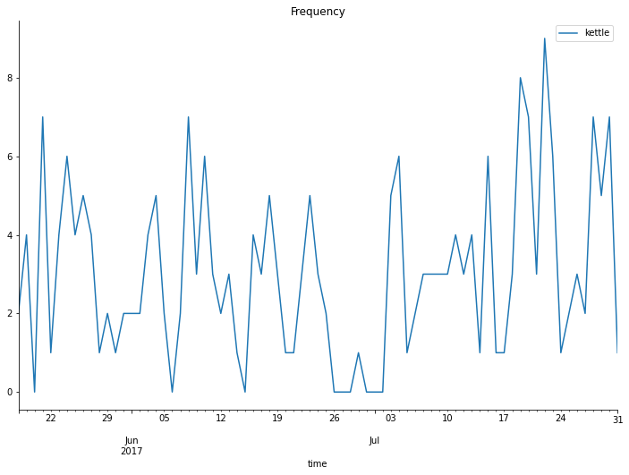

```python
import matplotlib.pyplot as plt
import seaborn as sns
%matplotlib inline

iidata=ndata["a"].resample("D").count()
iiidata=iidata["2017-05":"2017-07"]
iiidata

iiidata.plot(figsize=(12,8))
plt.legend(["kettle"])
plt.title("Frequency")
sns.despine()
```

The above figure shows use of kettle during two months. It seems that the frequency reached to peak usually twice a week, and the peaks were in the middle of the week. In the last week in June, home105 didn't use the kettle much often as it should have, maybe user was out or had some other reasons. But generally, the tendency of using kettle for Home105 was rising as time went by. The average frequency in July obviously was higher than that in May. Probably it was due to the season and temperature changing.

In the following, I chose three months: May 2017, August 2017, December 2017 to see the frequencies change in all recorded appliances.

What I want to find out are the followings:

1. What was the tendency of Home105 using different appliances?
2. Did the tendency change as times went by? What could be the reasons?

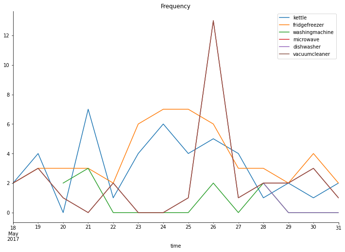

```python
import matplotlib.pyplot as plt
import seaborn as sns
%matplotlib inline

iidata=ndata["a"].resample("D").count()
iiidata=iidata["2017-05":"2017-05"]

iidata1=ndata1["a"].resample("D").count()
iiidata1=iidata1["2017-05":"2017-05"]

iidata2=ndata2["a"].resample("D").count()
iiidata2=iidata2["2017-05":"2017-05"]

iidata3=ndata3["a"].resample("D").count()
iiidata3=iidata3["2017-05":"2017-05"]

iidata4=ndata4["a"].resample("D").count()
iiidata4=iidata4["2017-05":"2017-05"]

iidata5=ndata5["a"].resample("D").count()
iiidata5=iidata5["2017-05":"2017-05"]

iiidata.plot(figsize=(12,8))
iiidata1.plot(figsize=(12,8))
iiidata2.plot(figsize=(12,8))
iiidata3.plot(figsize=(12,8))
iiidata4.plot(figsize=(12,8))
iiidata5.plot(figsize=(12,8))
plt.legend(["kettle","fridgefreezer","washingmachine","microwave","dishwasher","vacuumcleaner"])
plt.title("Frequency")
sns.despine()
```

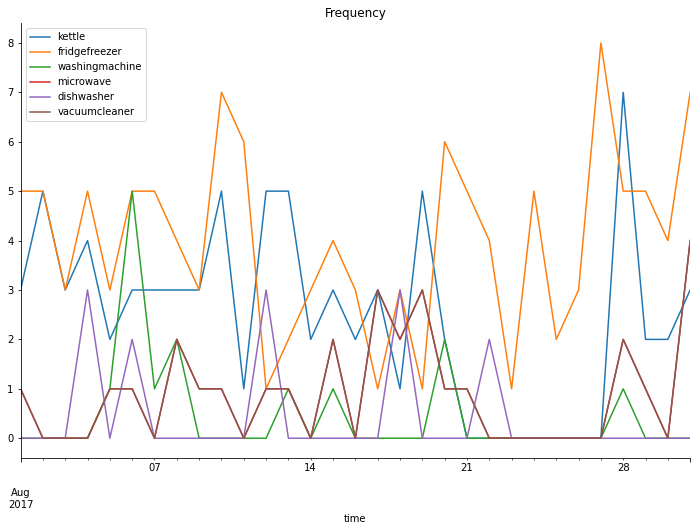

```python
import matplotlib.pyplot as plt
import seaborn as sns
%matplotlib inline

iidata=ndata["a"].resample("D").count()
iiidata=iidata["2017-08":"2017-08"]

iidata1=ndata1["a"].resample("D").count()
iiidata1=iidata1["2017-08":"2017-08"]

iidata2=ndata2["a"].resample("D").count()
iiidata2=iidata2["2017-08":"2017-08"]

iidata3=ndata3["a"].resample("D").count()
iiidata3=iidata3["2017-08":"2017-08"]

iidata4=ndata4["a"].resample("D").count()
iiidata4=iidata4["2017-08":"2017-08"]

iidata5=ndata5["a"].resample("D").count()
iiidata5=iidata5["2017-08":"2017-08"]

iiidata.plot(figsize=(12,8))
iiidata1.plot(figsize=(12,8))
iiidata2.plot(figsize=(12,8))
iiidata3.plot(figsize=(12,8))
iiidata4.plot(figsize=(12,8))
iiidata5.plot(figsize=(12,8))
plt.legend(["kettle","fridgefreezer","washingmachine","microwave","dishwasher","vacuumcleaner"])
plt.title("Frequency")
sns.despine()
```

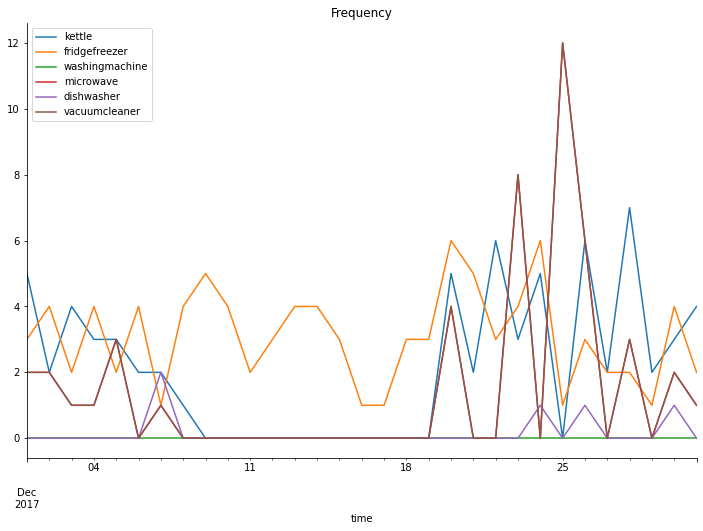

```python
import matplotlib.pyplot as plt
import seaborn as sns
%matplotlib inline

iidata=ndata["a"].resample("D").count()
iiidata=iidata["2017-12":"2017-12"]

iidata1=ndata1["a"].resample("D").count()
iiidata1=iidata1["2017-12":"2017-12"]

iidata2=ndata2["a"].resample("D").count()
iiidata2=iidata2["2017-12":"2017-12"]

iidata3=ndata3["a"].resample("D").count()
iiidata3=iidata3["2017-12":"2017-12"]

iidata4=ndata4["a"].resample("D").count()
iiidata4=iidata4["2017-12":"2017-12"]

iidata5=ndata5["a"].resample("D").count()
iiidata5=iidata5["2017-12":"2017-12"]

iiidata.plot(figsize=(12,8))
iiidata1.plot(figsize=(12,8))
iiidata2.plot(figsize=(12,8))
iiidata3.plot(figsize=(12,8))
iiidata4.plot(figsize=(12,8))
iiidata5.plot(figsize=(12,8))
plt.legend(["kettle","fridgefreezer","washingmachine","microwave","dishwasher","vacuumcleaner"])
plt.title("Frequency")
sns.despine()
```

From May to December, it seems that the most often used appliance for Home105 was the fridgefreezer, though kettle use usually kept a similar tendency as fridgefreezer use. Some new washing appliances were bought in May but Home105 actually tended to use them less and less often as times went by. Appliances were most frequently used in August. Perhaps due to the temperature rising and the tendency got down in December maybe because the cold weather made Home105 less willing to move.

## Proportions

In this part, I used pie charts to show the proportions of time Home105 spent on all recorded appliances. Here, I chose four time periods: Year 2017, May 2017, August 2017 and December 2017.

What I want to find out are the followings:

1. What was the most often used appliance in Home105?
2. Did time spend on different appliances change as times went by? What could be the reasons?

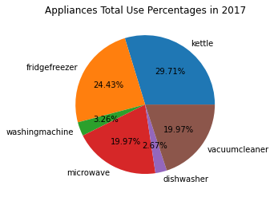

```python
import matplotlib.pyplot as plt
%matplotlib inline

labels=["kettle","fridgefreezer","washingmachine","microwave","dishwasher","vacuumcleaner"]
quants=[
iidata.sum(),
iidata1.sum(),
iidata2.sum(),
iidata3.sum(),
iidata4.sum(),
iidata5.sum()
]

plt.pie(quants,labels=labels,autopct="%1.2f%%")
plt.title("Appliances Total Use Percentages in 2017")

plt.show()
```

Among six recorded appliances, the kettle was most often used in Home105. Then the fridgefreezer ranked the second. Time using these two appliances accounted for more than 50% in 2017. However, the washing appliances, both the washingmachine and dishwasher, didn't cost too much time compared to others.

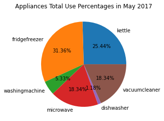

```python
import matplotlib.pyplot as plt
%matplotlib inline

labels=["kettle","fridgefreezer","washingmachine","microwave","dishwasher","vacuumcleaner"]
quants=[
iidata["2017-05":"2017-05"].sum(),
iidata1["2017-05":"2017-05"].sum(),
iidata2["2017-05":"2017-05"].sum(),
iidata3["2017-05":"2017-05"].sum(),
iidata4["2017-05":"2017-05"].sum(),
iidata5["2017-05":"2017-05"].sum()
]

plt.pie(quants,labels=labels,autopct="%1.2f%%")
plt.title("Appliances Total Use Percentages in May 2017")

plt.show()
```

In May 2017, it was still kettle and fridgefreezer that accounted for more than 50% time for Home105 spending on appliances. However, it seems Home105 used more fridgefreezer and washingmachine in May than in 2017. Proportions of time spent on microwave and vacuumcleaner didn't change a lot.

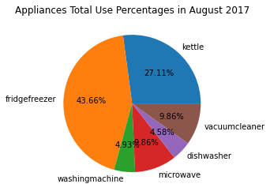

```python
import matplotlib.pyplot as plt
%matplotlib inline

labels=["kettle","fridgefreezer","washingmachine","microwave","dishwasher","vacuumcleaner"]
quants=[
iidata["2017-08":"2017-08"].sum(),
iidata1["2017-08":"2017-08"].sum(),
iidata2["2017-08":"2017-08"].sum(),
iidata3["2017-08":"2017-08"].sum(),
iidata4["2017-08":"2017-08"].sum(),
iidata5["2017-08":"2017-08"].sum()
]

plt.pie(quants,labels=labels,autopct="%1.2f%%")
plt.title("Appliances Total Use Percentages in August 2017")

plt.show()
```

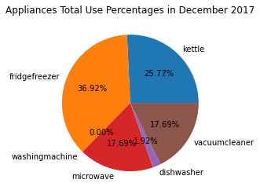

```python
import matplotlib.pyplot as plt
%matplotlib inline

labels=["kettle","fridgefreezer","washingmachine","microwave","dishwasher","vacuumcleaner"]
quants=[
iidata["2017-12":"2017-12"].sum(),
iidata1["2017-12":"2017-12"].sum(),
iidata2["2017-12":"2017-12"].sum(),
iidata3["2017-12":"2017-12"].sum(),
iidata4["2017-12":"2017-12"].sum(),
iidata5["2017-12":"2017-12"].sum()
]

plt.pie(quants,labels=labels,autopct="%1.2f%%")
plt.title("Appliances Total Use Percentages in December 2017")

plt.show()
```

Fridgefreezer using still accounted for a large proportion in December and the kettle use didn't change a lot again. However, proportions of time spent on microwave and vaccumcleaner rise again as what it was like in May while proportions of washing appliances got down to around 1%.

As what I have analyzed in frequency part above, kettle and fridgefreezer were two typical appliances more often used in Home105. Comparing the pie charts, the proportions of time spent on kettle didn't change so much through the year. The fridgefreezer was more often used during August and December, and the probable reason was season changing, summer and winter. Proportions of microwave and vacuumcleaner use were less stable than that of kettle use but still usually accounted for 33%. For washing appliances, they both accounts for rather small part through the year, and when as months changing from May to December, it seems time spent on these two appliances gradually cut. when it was December, Home105 seldom used these two appliances at all. Maybe these two appliances didn't work well gradually so Home105 couldn't use them. Or Home105 just found out they were useless in daily routine.

## 1.2 Two More IDEAL Homes

In the following, I used the same programming lines as in analyzing Home105 to other 2 homes in IDEAL file: Home90, Home106. I skipped the detailed analysis for each appliance. Instead, I directly put them altogether in a plot for comparisons.

```python
import pandas as pd
file=pd.read_csv("home90_kitchen957_sensor4858_electric-appliance_kettle.csv", header=0, names=["time","power"])
lst=file["time"]
nlst=set(lst)
if len(nlst)==len(lst):
    print("OK")
else:
    print("NO")
```

```
OK
```

## Routines

By uploading 2 more homes, now I have Home90/105/106 here. For Home90/105/106, they all had records on 2017-05-28, so I am going to compare the similarities and differences for these homes on that day.

What I want to find out are the followings:

1. Were there any similarities on routine for Home90/105/106 on 2017-05-28?
2. How about the differences?

### Home90

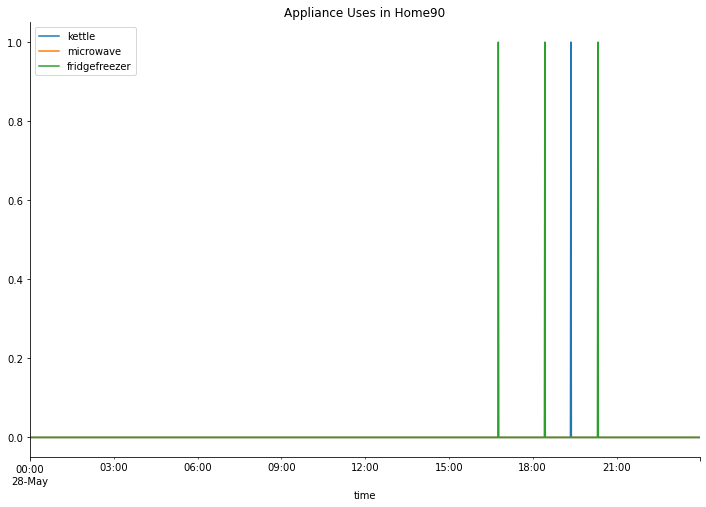

```python
import pandas as pd
import matplotlib.pyplot as plt
import seaborn as sns
%matplotlib inline

#open csvfiles, add column names and a new column
data90_1=pd.read_csv("home90_kitchen957_sensor4858_electric-appliance_kettle.csv", header=0, names=["time","power"])
data90_1=pd.concat([data90_1,pd.DataFrame(columns=list("a"))])
data90_1["a"]=0

data90_2=pd.read_csv("home90_kitchen957_sensor4859_electric-appliance_microwave.csv", header=0, names=["time","power"])
data90_2=pd.concat([data90_2,pd.DataFrame(columns=list("a"))])
data90_2["a"]=0

data90_3=pd.read_csv("home90_kitchen957_sensor4860_electric-appliance_fridgefreezer.csv", header=0, names=["time","power"])
data90_3=pd.concat([data90_3,pd.DataFrame(columns=list("a"))])
data90_3["a"]=0

#find the starting points of appliance use
data90_1["result"]=data90_1["power"].shift(-1)-data90_1["power"]
data90_1.loc[data90_1["result"]>2000,"a"]=1
ndata90_1=data90_1[data90_1["a"]==1]
ndata90_1.index=pd.to_datetime(ndata90_1["time"])

data90_2["result"]=data90_2["power"].shift(-1)-data90_2["power"]
data90_2.loc[data90_2["result"]>1000,"a"]=1
ndata90_2=data90_2[data90_2["a"]==1]
ndata90_2.index=pd.to_datetime(ndata90_2["time"])

data90_3["result"]=data90_3["power"].shift(-1)-data90_3["power"]
data90_3.loc[data90_3["result"]>700,"a"]=1
ndata90_3=data90_3[data90_3["a"]==1]
ndata90_3.index=pd.to_datetime(ndata90_3["time"])

#combine plots to see applicance use in a setted time period
nndata90_1=ndata90_1['time'].resample('T').count()
nnndata90_1=nndata90_1['2017-05-28':'2017-05-28']
nnndata90_1.plot(figsize=(12,8))

nndata90_2=ndata90_2['time'].resample('T').count()
nnndata90_2=nndata90_2['2017-05-28':'2017-05-28']
nnndata90_2.plot(figsize=(12,8))

nndata90_3=ndata90_3['time'].resample('T').count()
nnndata90_3=nndata90_3['2017-05-28':'2017-05-28']
nnndata90_3.plot(figsize=(12,8))

plt.legend(["kettle","microwave","fridgefreezer"])
plt.title("Appliance Uses in Home90")
sns.despine()
```

On 2017-05-28, Home90 used fridgefreezer and kettle. Home90 opened the fridgefreezer 3 times in the evening, at around 17pm, 19pm and 21pm and only used the kettle once at around 20pm. Mircowave wasn't used at that day.

### Home106

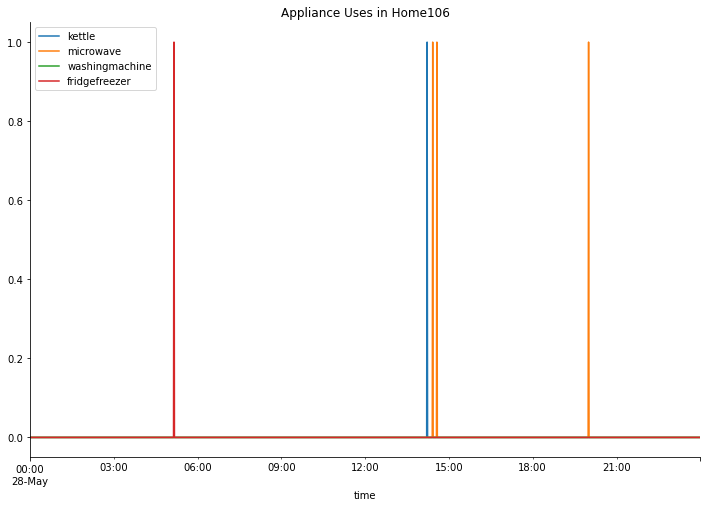

```python
import pandas as pd
import matplotlib.pyplot as plt
import seaborn as sns
%matplotlib inline

#open csvfiles, add column names and a new column
data106_1=pd.read_csv("home106_kitchen1085_sensor5210_electric-appliance_kettle.csv", header=0, names=["time","power"])
data106_1=pd.concat([data106_1,pd.DataFrame(columns=list("a"))])
data106_1["a"]=0

data106_2=pd.read_csv("home106_kitchen1085_sensor5211_electric-appliance_microwave.csv", header=0, names=["time","power"])
data106_2=pd.concat([data106_2,pd.DataFrame(columns=list("a"))])
data106_2["a"]=0

data106_3=pd.read_csv("home106_kitchen1085_sensor5212_electric-appliance_washingmachine.csv", header=0, names=["time","power"])
data106_3=pd.concat([data106_3,pd.DataFrame(columns=list("a"))])
data106_3["a"]=0

data106_4=pd.read_csv("home106_kitchen1085_sensor5213_electric-appliance_fridgefreezer.csv", header=0, names=["time","power"])
data106_4=pd.concat([data106_4,pd.DataFrame(columns=list("a"))])
data106_4["a"]=0

#find the starting points of appliance use
data106_1["result"]=data106_1["power"].shift(-1)-data106_1["power"]
data106_1.loc[data106_1["result"]>2000,"a"]=1
ndata106_1=data106_1[data106_1["a"]==1]
ndata106_1.index=pd.to_datetime(ndata106_1["time"])

data106_2["result"]=data106_2["power"].shift(-1)-data106_2["power"]
data106_2.loc[data106_2["result"]>1000,"a"]=1
ndata106_2=data106_2[data106_2["a"]==1]
ndata106_2.index=pd.to_datetime(ndata106_2["time"])

data106_3["result"]=data106_3["power"].shift(-1)-data106_3["power"]
data106_3.loc[data106_3["result"]>2000,"a"]=1
ndata106_3=data106_3[data106_3["a"]==1]
ndata106_3.index=pd.to_datetime(ndata106_3["time"])

data106_4["result"]=data106_4["power"].shift(-1)-data106_4["power"]
data106_4.loc[data106_4["result"]>100,"a"]=1
ndata106_4=data106_4[data106_4["a"]==1]
ndata106_4.index=pd.to_datetime(ndata106_4["time"])

#combine plots to see applicance use in a setted time period
nndata106_1=ndata106_1['time'].resample('T').count()
nnndata106_1=nndata106_1['2017-05-28':'2017-05-28']
nnndata106_1.plot(figsize=(12,8))

nndata106_2=ndata106_2['time'].resample('T').count()
nnndata106_2=nndata106_2['2017-05-28':'2017-05-28']
nnndata106_2.plot(figsize=(12,8))

nndata106_3=ndata106_3['time'].resample('T').count()
nnndata106_3=nndata106_3['2017-05-28':'2017-05-28']
nnndata106_3.plot(figsize=(12,8))

nndata106_4=ndata106_4['time'].resample('T').count()
nnndata106_4=nndata106_4['2017-05-28':'2017-05-28']
nnndata106_4.plot(figsize=(12,8))

plt.legend(["kettle","microwave","washingmachine","fridgefreezer"])
plt.title("Appliance Uses in Home106")
sns.despine()
```

On 2017-05-28, Home106 opened the fridgefreezer early in the morning at around 6am. Kettle was used once in the afternoon at around 15pm. Microwave was used at around 15pm and 21pm. The washingmachine didn't use on that day.

## Frequencies

In the following, I chose two months: May 2017, December 2017 to see the frequency changes in different homes.

What I want to find out are the followings:

1. Compare different homes in May, was there a similar or different tendency in using appliances?
2. Compare each home in December, did there anything change as time went by? Did this change occur in all homes?

### May 2017

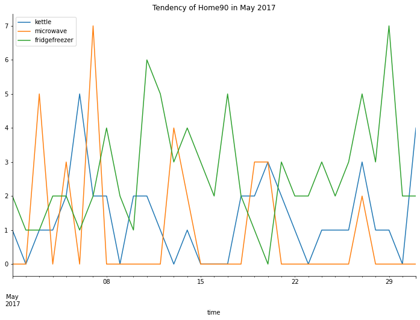

```python
#Home90
import matplotlib.pyplot as plt
import seaborn as sns
%matplotlib inline

iidata90_1=ndata90_1["a"].resample("D").count()
iiidata90_1=iidata90_1["2017-05":"2017-05"]

iidata90_2=ndata90_2["a"].resample("D").count()
iiidata90_2=iidata90_2["2017-05":"2017-05"]

iidata90_3=ndata90_3["a"].resample("D").count()
iiidata90_3=iidata90_3["2017-05":"2017-05"]

iiidata90_1.plot(figsize=(12,8))
iiidata90_2.plot(figsize=(12,8))
iiidata90_3.plot(figsize=(12,8))

plt.legend(["kettle","microwave","fridgefreezer"])
plt.title("Tendency of Home90 in May 2017")
sns.despine()
```

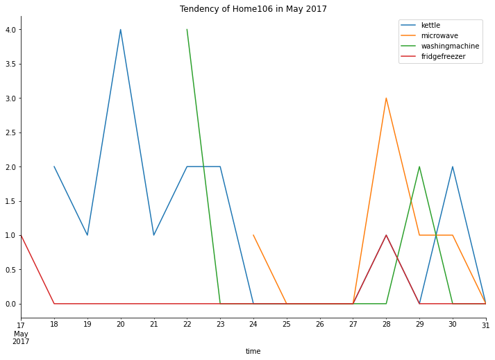

```python
#Home106
import matplotlib.pyplot as plt
import seaborn as sns
%matplotlib inline

iidata106_1=ndata106_1["a"].resample("D").count()
iiidata106_1=iidata106_1["2017-05":"2017-05"]

iidata106_2=ndata106_2["a"].resample("D").count()
iiidata106_2=iidata106_2["2017-05":"2017-05"]

iidata106_3=ndata106_3["a"].resample("D").count()
iiidata106_3=iidata106_3["2017-05":"2017-05"]

iidata106_4=ndata106_4["a"].resample("D").count()
iiidata106_4=iidata106_4["2017-05":"2017-05"]

iiidata106_1.plot(figsize=(12,8))
iiidata106_2.plot(figsize=(12,8))
iiidata106_3.plot(figsize=(12,8))
iiidata106_4.plot(figsize=(12,8))

plt.legend(["kettle","microwave","washingmachine","fridgefreezer"])
plt.title("Tendency of Home106 in May 2017")
sns.despine()
```

Home106 used the kettle and washingmachine very often in the middle of May, but didn't use any recorded appliances for two days and then started to use all recorded appliances again in the last 5 days of May. Microwave were more used in the last period while kettle and washing machine were still used though less than how they were used at first. For the fridgefreezer, it seems Home106 didn't use it so often in May, typically open it once a week.

Comparing Home90/105/106's routines for one month, all homes used the kettle quite often. While Home90 and Home105 also used the fridgefreezer a lot, this wasn't seen in Home106. For other appliances, Home105/106 both had the washingmachine. However, the condition of use was quite different. In Home105, the washingmachine was seldom used while in home106, tendency of using washingmachine was the same as using a kettle and was more often used.

### Dec 2017

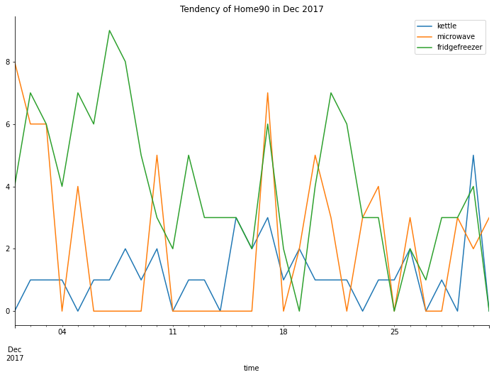

```python
#Home90
import matplotlib.pyplot as plt
import seaborn as sns
%matplotlib inline

iidata90_1=ndata90_1["a"].resample("D").count()
iiidata90_1=iidata90_1["2017-12":"2017-12"]

iidata90_2=ndata90_2["a"].resample("D").count()
iiidata90_2=iidata90_2["2017-12":"2017-12"]

iidata90_3=ndata90_3["a"].resample("D").count()
iiidata90_3=iidata90_3["2017-12":"2017-12"]

iiidata90_1.plot(figsize=(12,8))
iiidata90_2.plot(figsize=(12,8))
iiidata90_3.plot(figsize=(12,8))

plt.legend(["kettle","microwave","fridgefreezer"])
plt.title("Tendency of Home90 in Dec 2017")
sns.despine()
```

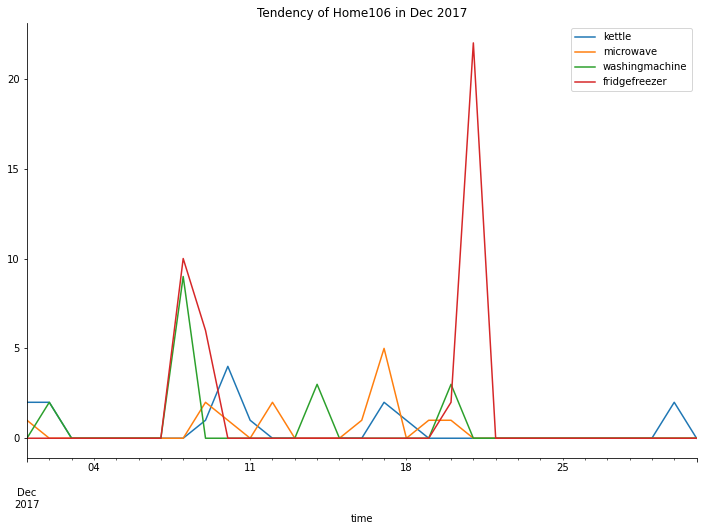

```python
#Home106
import matplotlib.pyplot as plt
import seaborn as sns
%matplotlib inline

iidata106_1=ndata106_1["a"].resample("D").count()
iiidata106_1=iidata106_1["2017-12":"2017-12"]

iidata106_2=ndata106_2["a"].resample("D").count()
iiidata106_2=iidata106_2["2017-12":"2017-12"]

iidata106_3=ndata106_3["a"].resample("D").count()
iiidata106_3=iidata106_3["2017-12":"2017-12"]

iidata106_4=ndata106_4["a"].resample("D").count()
iiidata106_4=iidata106_4["2017-12":"2017-12"]

iiidata106_1.plot(figsize=(12,8))
iiidata106_2.plot(figsize=(12,8))
iiidata106_3.plot(figsize=(12,8))
iiidata106_4.plot(figsize=(12,8))

plt.legend(["kettle","microwave","washingmachine","fridgefreezer"])
plt.title("Tendency of Home106 in Dec 2017")
sns.despine()
```

Home106 only often used all recorded appliances in the middle of December, during which the frequency of fridgefreezer soared to the top in 20th Dec. Compared to how Home106 used appliances in May, the frequency of kettle, washingmachine and microwave didn't change a lot. But there was a significant difference in using fridgefreezer, perhaps due to the weather and the festival.

## Proportions

In the following, the comparisons are within homes first and then summarize in a general way.

What I want to find out are the followings:

1. What was the most often used appliance in each home?
2. Were there any changes as times went by? What could be the reasons?

### Home90

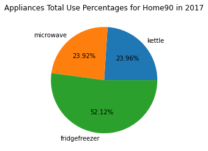

```python
import matplotlib.pyplot as plt
%matplotlib inline

labels=["kettle","microwave","fridgefreezer"]
quants=[
iidata90_1.sum(),
iidata90_2.sum(),
iidata90_3.sum()
]

plt.pie(quants,labels=labels,autopct="%1.2f%%")
plt.title("Appliances Total Use Percentages for Home90 in 2017")

plt.show()
```

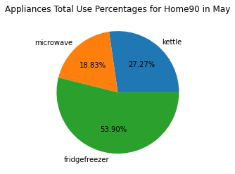

```python
import matplotlib.pyplot as plt
%matplotlib inline

labels=["kettle","microwave","fridgefreezer"]
quants=[
iidata90_1["2017-05":"2017-05"].sum(),
iidata90_2["2017-05":"2017-05"].sum(),
iidata90_3["2017-05":"2017-05"].sum()
]

plt.pie(quants,labels=labels,autopct="%1.2f%%")
plt.title("Appliances Total Use Percentages for Home90 in May")

plt.show()
```

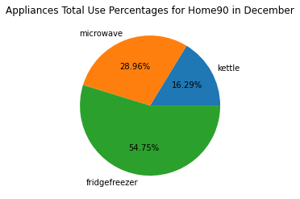

```python
import matplotlib.pyplot as plt
%matplotlib inline

labels=["kettle","microwave","fridgefreezer"]
quants=[
iidata90_1["2017-12":"2017-12"].sum(),
iidata90_2["2017-12":"2017-12"].sum(),
iidata90_3["2017-12":"2017-12"].sum()
]

plt.pie(quants,labels=labels,autopct="%1.2f%%")
plt.title("Appliances Total Use Percentages for Home90 in December")

plt.show()
```

In Home90, the proposition of fridgefreezer use didn't change a lot but time distributed in microwave and kettle use had a significant difference. Home90 used more microwave in December than in May and the proposition of microwave use in December was higher than the average in year 2017 while the proposition in May was lower.

### Home106

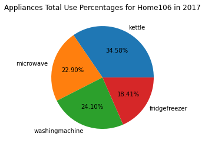

```python
import matplotlib.pyplot as plt
%matplotlib inline

labels=["kettle","microwave","washingmachine","fridgefreezer"]
quants=[
iidata106_1.sum(),
iidata106_2.sum(),
iidata106_3.sum(),
iidata106_4.sum()
]

plt.pie(quants,labels=labels,autopct="%1.2f%%")
plt.title("Appliances Total Use Percentages for Home106 in 2017")

plt.show()
```

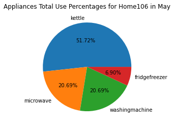

```python
import matplotlib.pyplot as plt
%matplotlib inline

labels=["kettle","microwave","washingmachine","fridgefreezer"]
quants=[
iidata106_1["2017-05":"2017-05"].sum(),
iidata106_2["2017-05":"2017-05"].sum(),
iidata106_3["2017-05":"2017-05"].sum(),
iidata106_4["2017-05":"2017-05"].sum()
]

plt.pie(quants,labels=labels,autopct="%1.2f%%")
plt.title("Appliances Total Use Percentages for Home106 in May")

plt.show()
```

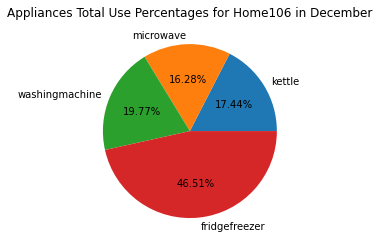

```python
import matplotlib.pyplot as plt
%matplotlib inline

labels=["kettle","microwave","washingmachine","fridgefreezer"]
quants=[
iidata106_1["2017-12":"2017-12"].sum(),
iidata106_2["2017-12":"2017-12"].sum(),
iidata106_3["2017-12":"2017-12"].sum(),
iidata106_4["2017-12":"2017-12"].sum()
]

plt.pie(quants,labels=labels,autopct="%1.2f%%")
plt.title("Appliances Total Use Percentages for Home106 in December")

plt.show()
```

Interesting thing happened in kettle and fridgefreezer use in May and December. Compared to prporsitions in the whole year, it seems Home106 used kettle so much often in May and so little in December while for fridgefreezer, the condition dramatically reversed.

# 2. SMILE

In the following five homes (1868,1874,2059,2688,4206), the same appliance they all had was a microwave, so I only picked out microwave csvfiles for analysis.

Since for SMILE Homes, I got data of home users, like ages and locations. Next, I would like to see if there was any relationship between these two independent variables with average frequency of using microwave in 5 homes.

```python
import pandas as pd
file=pd.read_excel("Energy data participants.xlsx")
file
```

|  | ID | Gender | DateOfBirth | Age | StaffPlanConditions | CareSysCondition | Location |
| --- | --- | --- | --- | --- | --- | --- | --- |
| 0 | 2059 | M | 1954-09-21 00:00:00 | 66 | None | None | Aberdeen |
| 1 | 4206 | M | 1954-12-22 00:00:00 | 54 | None | Mobility Issues | Livingston |
| 2 | 1868 | F | 1959-06-29 00:00:00 | 61 | None | Cerebral Palsy | Aberdeen |
| 3 | 2059 | M | 1954-09-21 00:00:00 | 66 | None | Stroke | Aberdeen |
| 4 | 2688 | M | 1967-08-19 00:00:00 | 53 | None | Mental Health Issue | Edinburgh |
| 5 | 2583 | M | Nil | 70+ | None | COPD | Edinburgh |
| 6 | 1874 | M | 1952-10-01 00:00:00 | 68 | None | Brain Injury | Aberdeen |
| 7 | 5713 | M | Nil | Nil | None | ? | Edinburgh |

```python
file.drop_duplicates("ID","first",inplace=True)
nfile=file.drop([5,7])
nfile.sort_values("ID",inplace=True)
nfile
```

|  | ID | Gender | DateOfBirth | Age | StaffPlanConditions | CareSysCondition | Location |
| --- | --- | --- | --- | --- | --- | --- | --- |
| 2 | 1868 | F | 1959-06-29 00:00:00 | 61 | None | Cerebral Palsy | Aberdeen |
| 6 | 1874 | M | 1952-10-01 00:00:00 | 68 | None | Brain Injury | Aberdeen |
| 0 | 2059 | M | 1954-09-21 00:00:00 | 66 | None | None | Aberdeen |
| 4 | 2688 | M | 1967-08-19 00:00:00 | 53 | None | Mental Health Issue | Edinburgh |
| 1 | 4206 | M | 1954-12-22 00:00:00 | 54 | None | Mobility Issues | Livingston |

```python
print(nfile["Age"].max())
print(nfile["Age"].min())
print(nfile["Age"].mean())
```

```
68
53
60.4
```

```python
import pandas as pd
import matplotlib.pyplot as plt
import seaborn as sns
%matplotlib inline

#Home1868
data1868=pd.read_csv("home1868_room1868_sensor20508_electric-appliance_microwave.csv", header=0, names=["time","power"])
data1868=pd.concat([data1868,pd.DataFrame(columns=list("a"))])
data1868["a"]=0
data1868["result"]=data1868["power"].shift(-1)-data1868["power"]
data1868.loc[data1868["result"]>1000,"a"]=1
ndata1868=data1868[data1868["a"]==1]
ndata1868.index=pd.to_datetime(ndata1868["time"])

#Home1874
data1874=pd.read_csv("home1874_room1874_sensor80508_electric-appliance_microwave.csv", header=0, names=["time","power"])
data1874=pd.concat([data1874,pd.DataFrame(columns=list("a"))])
data1874["a"]=0
data1874["result"]=data1874["power"].shift(-1)-data1874["power"]
data1874.loc[data1874["result"]>1000,"a"]=1
ndata1874=data1874[data1874["a"]==1]
ndata1874.index=pd.to_datetime(ndata1874["time"])

#Home2059
data2059=pd.read_csv("home2059_room2059_sensor20508_electric-appliance_microwave.csv", header=0, names=["time","power"])
data2059=pd.concat([data2059,pd.DataFrame(columns=list("a"))])
data2059["a"]=0
data2059["result"]=data2059["power"].shift(-1)-data2059["power"]
data2059.loc[data2059["result"]>1000,"a"]=1
ndata2059=data2059[data2059["a"]==1]
ndata2059.index=pd.to_datetime(ndata2059["time"])

#Home2688
data2688=pd.read_csv("home2688_room2688_sensor30508_electric-appliance_microwave.csv", header=0, names=["time","power"])
data2688=pd.concat([data2688,pd.DataFrame(columns=list("a"))])
data2688["a"]=0
data2688.loc[data2688["power"]>1000,"a"]=1
ndata2688=data2688[data2688["a"]==1]
ndata2688.index=pd.to_datetime(ndata2688["time"])

#Home4206
data4206=pd.read_csv("home4206_room4206_sensor80508_electric-appliance_microwave.csv", header=0, names=["time","power"])
data4206=pd.concat([data4206,pd.DataFrame(columns=list("a"))])
data4206["a"]=0
data4206.loc[data4206["power"]>1000,"a"]=1
ndata4206=data4206[data4206["a"]==1]
ndata4206.index=pd.to_datetime(ndata4206["time"])
```

```python
import matplotlib.pyplot as plt
import seaborn as sns
%matplotlib inline

iidata1868=ndata1868["a"].resample("D").count()
iidata1874=ndata1874["a"].resample("D").count()
iidata2059=ndata2059["a"].resample("D").count()
iidata2688=ndata2688["a"].resample("D").count()
iidata4206=ndata4206["a"].resample("D").count()

a1868_y=iidata1868.mean()
a1874_y=iidata1874.mean()
a2059_y=iidata2059.mean()
a2688_y=iidata2688.mean()
a4206_y=iidata4206.mean()

alst_y=[a1868_y,a1874_y,a2059_y,a2688_y,a4206_y]
```

```python
import pandas as pd
file=pd.read_excel("Energy data participants.xlsx")
file.drop_duplicates("ID","first",inplace=True)
nfile=file.drop([5,7])
nfile.sort_values("ID",inplace=True)
nfile["Average"]=alst_y
nfile
```

|  | ID | Gender | DateOfBirth | Age | StaffPlanConditions | CareSysCondition | Location | Average |
| --- | --- | --- | --- | --- | --- | --- | --- | --- |
| 2 | 1868 | F | 1959-06-29 00:00:00 | 61 | None | Cerebral Palsy | Aberdeen | 1.860714 |
| 6 | 1874 | M | 1952-10-01 00:00:00 | 68 | None | Brain Injury | Aberdeen | 1.799270 |
| 0 | 2059 | M | 1954-09-21 00:00:00 | 66 | None | None | Aberdeen | 5.065891 |
| 4 | 2688 | M | 1967-08-19 00:00:00 | 53 | None | Mental Health Issue | Edinburgh | 1.293907 |
| 1 | 4206 | M | 1954-12-22 00:00:00 | 54 | None | Mobility Issues | Livingston | 1.035336 |

```python
nfile["Age"]=nfile["Age"].astype("float64")
nfile.info()
```

```
<class 'pandas.core.frame.DataFrame'>
Int64Index: 5 entries, 2 to 1
Data columns (total 8 columns):
 #   Column               Non-Null Count  Dtype
---  ------               --------------  -----
 0   ID                   5 non-null      int64
 1   Gender               5 non-null      object
 2   DateOfBirth          5 non-null      object
 3   Age                  5 non-null      float64
 4   StaffPlanConditions  5 non-null      object
 5   CareSysCondition     5 non-null      object
 6   Location             5 non-null      object
 7   Average              5 non-null      float64
dtypes: float64(2), int64(1), object(5)
memory usage: 360.0+ bytes
```

```python
print(nfile["Age"].corr(nfile["Average"]))
```

```
0.6065716210554641
```

r=0.61, this means that the frequencies of using microwave in 2020 had a moderate positive correlation with ages of home users.

```python
print(set(nfile["Location"]))
```

```
{'Edinburgh', 'Aberdeen', 'Livingston'}
```

```python
#give an "ID" for each location
nfile["nlocation"]=[1,1,1,2,3]
nfile
```

|  | ID | Gender | DateOfBirth | Age | StaffPlanConditions | CareSysCondition | Location | Average | nlocation |
| --- | --- | --- | --- | --- | --- | --- | --- | --- | --- |
| 2 | 1868 | F | 1959-06-29 00:00:00 | 61.0 | None | Cerebral Palsy | Aberdeen | 1.860714 | 1 |
| 6 | 1874 | M | 1952-10-01 00:00:00 | 68.0 | None | Brain Injury | Aberdeen | 1.799270 | 1 |
| 0 | 2059 | M | 1954-09-21 00:00:00 | 66.0 | None | None | Aberdeen | 5.065891 | 1 |
| 4 | 2688 | M | 1967-08-19 00:00:00 | 53.0 | None | Mental Health Issue | Edinburgh | 1.293907 | 2 |
| 1 | 4206 | M | 1954-12-22 00:00:00 | 54.0 | None | Mobility Issues | Livingston | 1.035336 | 3 |

```python
print(nfile["nlocation"].corr(nfile["Average"]))
```

```
-0.5594668160484849
```

r=-0.56, this means the frequencies of using microwave in 2020 had a moderate negative correlation with locations of home users. More specifically, home user living in Livingston tended to use microwave less often than the user living in Aberdeen and home user living in Edinburgh were in the middle.

# Part 3: Reflection and Hypotheses

## Reflection

My reflection mainly focuses on some feedbacks on the process of dealing with data. I first thought the data was easy to analyze because in each csvfile there were only two rows. However, problems came gradually. First, I couldn't split the "time" into smaller items like year, month, day...so I needed to take them as an entirety. Then, I found that the time column was not continuous so I could not have a fixed x-axis. The biggest problem was to sort out the start points in each file. Two new tips I learned from here were: 1. add a new column and use 0/1 to label; 2. if it was really hard to delete the items, then just put them aside and use "reverse" to get the dataframe I want. These two tips really helped me come over the most difficult parts in analyzing all files. Finally, consistent data types and variable names always needs to be kept in mind. Sometimes, the bug was so small to figure out and usually it was the mistake of consistency. Programming needs patience and sometimes a little brain-twister. I suppose these feedbacks are not only useful for this time and can be applied to later programming.

## Hypotheses

1. Frequency of using appliances has a possitive correlation with the home user's age; Now I find such possitive correlation in microwave use, so I wonder if this condition can also be seen in other appliances. To test the hypotheses, I need more appliances data in SMILE Homes or personal information in IDEAL Homes from the data holder.
2. Frequency of using appliances has a correlation with the home user's location, maybe also linking to the latitude of locations; I have found a correlation between microwave use and locations. The reason I mention the latitude of locations is because I can see a tendency in the chart above. Aberdeen is the northest location among three, and the top frequency of microwave use is also based there while Livingston is the southest among three, and people least frequently using microwave just lives there! To test the hypotheses, the same as in hypotheses 1, I need more appliances data or personal information. And specifically for this hypotheses, I also need to check the latitudes of each locations from Google.
3. Each home has its own routine of using appliances in a day. From analyzing Home105, I find some small routines alike things only from 3 days. Perhaps when I go over through more dates and by dynamically showing the timelines in a day, I will finally get a fixed routine in each home.